# Homework 7-1 Logistic Regression

Nithin Mahesh

### Logistic Regression

In this homework, you will fit logistic regression classifiers to data. You will evaluate the quality of the model’s predictions by calculating the misclassification rate. You will plot the model’s ROC curve for all prediction thresholds, and calculate the auc. You will then use the performance function in the ROCR library to calculate an optimal threshold and evaluate the classification of the model using that threshold.

Next, you will fit another model on the data and add it’s ROC curve to the first model. You will compare the performance of these two models.

Finally, you will perform K-fold cross validation and report on the performance characteristics of your model.

The data comes from a study of factors relating to presence/absence of levee failure at sites on the Mississippi River.

Predicted label: failure 0=no, 1=yes

Predictors: river mile  
Site underlain by coarse-grain channel fill (sediment) Borrow pit indicator Meander location (1=Inside bend, 2=outside bend, 3=chute, 4=straight) channel width floodway width constriction factor land cover type (1=open water, 2=grassy, 3=agricultural, 4=forest) vegetative buffer width channel sinuosity dredging intensity bank revetement

The data is found in the file “levee.csv”.

Q1 (3pts): Read in the data file, convert the “failure” column to a factor with levels 0=no, 1=yes.

```r
library(ROCR)
levee.df = read.csv("levee.csv")
levee.df$failure = factor(levee.df$failure)
levels(levee.df$failure) = c("No", "Yes")
```

#### Logistic regression analysis

```r
data.size<-nrow(levee.df)
train.size<-0.20

set.seed(12345)
train.row.nums<-sample(1:data.size, data.size*train.size, replace=FALSE)
train.data<-subset(levee.df[train.row.nums,])

test.row.nums<-setdiff(1:data.size,train.row.nums)
test.data<-subset(levee.df[test.row.nums,])

true.labels<-levee.df$failure[test.row.nums]
```

Q3 (2pts): Fit a logistic regression model using all predictors.

```r
mod = glm(failure ~ .,data = train.data, family = binomial(logit))
summary(mod)
```

```
##
## Call:
## glm(formula = failure ~ ., family = binomial(logit), data = train.data)
##
## Deviance Residuals:
##     Min       1Q   Median       3Q      Max
## -1.6321  -0.9446  -0.5086   1.1149   1.6297
##
## Coefficients:
##                Estimate Std. Error z value Pr(>|z|)
## (Intercept)  -1.040e+00  3.981e+00  -0.261    0.794
## mile         -3.445e-04  2.316e-03  -0.149    0.882
## sediments    -4.165e-01  9.737e-01  -0.428    0.669
## borrowpit     8.266e-01  1.564e+00   0.528    0.597
## meander       8.152e-02  4.571e-01   0.178    0.858
## chanwidth    -1.219e-03  8.763e-04  -1.391    0.164
## fldwidth      5.517e-04  4.441e-04   1.242    0.214
## constriction -3.579e-01  9.074e-01  -0.394    0.693
## cover         2.385e-01  6.359e-01   0.375    0.708
## vegwidth     -7.943e-04  5.623e-04  -1.413    0.158
## sinuosity     6.518e-01  2.233e+00   0.292    0.770
## dredging      1.916e-07  2.251e-06   0.085    0.932
## revetment    -1.848e+01  2.400e+03  -0.008    0.994
##
## (Dispersion parameter for binomial family taken to be 1)
##
##     Null deviance: 41.054  on 29  degrees of freedom
## Residual deviance: 34.911  on 17  degrees of freedom
## AIC: 60.911
##
## Number of Fisher Scoring iterations: 15
```

Q4 (5pts): Using the model above, call “predict” on the test data, not including the class label column. Create a vector of labels that are predictions of “failure”. As before, create a vector of “no” labels the size of the test data, then change to “yes” whenever the predicted value is strictly greater than the classification threshold. Use 0.5 as the threshold for classification.

```r
model.predictions<-predict(mod, newdata= test.data[,-1], type="response")
class.threshold<-0.5
pred.labels<-rep("no",length(true.labels))
pred.labels[model.predictions>class.threshold]="yes"
```

Q5 (5pts): Calculate and display the misclassification rate and display the confusion matrix.

```r
num.incorrect.labels<-sum(true.labels!=pred.labels)
num.incorrect.labels/length(true.labels)
```

```
## [1] 1
```

```r
conf.matrix <- table(true.labels, pred.labels)
conf.matrix
```

```
##            pred.labels
## true.labels no yes
##         No  29  30
##         Yes 36  27
```

Q6 (5pts): Plot an ROC curve of this model using the “prediction” and “performance” functions in the ROCR library. Include a diagonal, dotted line to show the “random, 50-50 classifier”.

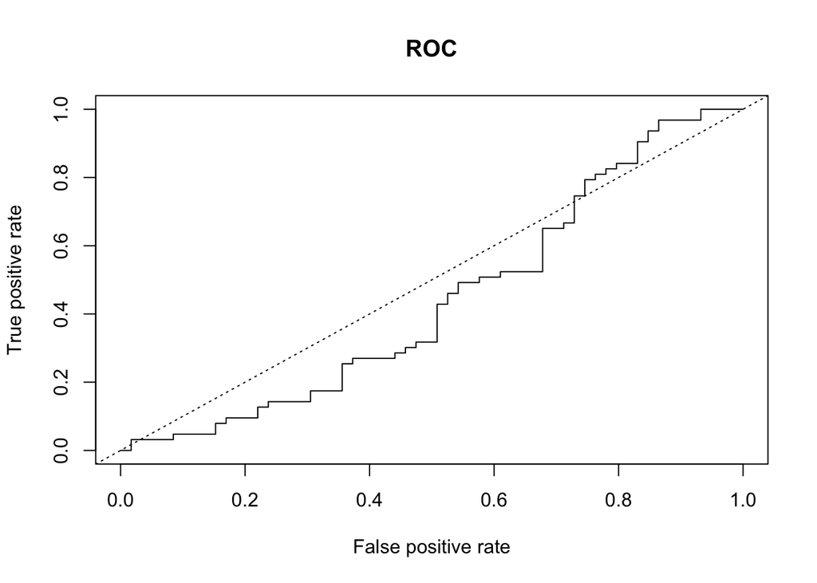

```r
pred<-prediction(model.predictions,true.labels)
perf<-performance(pred,'tpr','fpr')
plot(perf,main="ROC")
abline(0,1,lty=3) #Adds the x=y line, representing a random 50-50 prediction
```

Q7 (5pts): Calculate and display the AUC for this classifier.

```r
perf.auc<- performance(pred,'auc',fpr.stop=1)
auc<-slot(perf.auc,"y.values")[[1]]
auc
```

```
## [1] 0.4404089
```